# 課題4：random coefficient logit の推定と合併分析

計量経済学II

作者

Kei Ikegami

**重要この課題のねらい**

第4回でやった **ミニBLP**（縮小写像 → IV回帰 → GMM）と **合併分析**（Bertrand-Nash からの限界費用逆算 → 合併後均衡）を、自分の手で最初から最後まで通す。この回の技術を全部使う、重めの課題だ。焦らず、まずデータを作り、収束を確かめ、それから推定に進もう。

- **Part 1**：J=3・T=60市場の市場データを、価格が内生な形で自作する（40点）。
- **Part 2**：$\sigma$ のグリッドで GMM を回し、plain logit との弾力性比較、財1・2の合併分析、審査官向けの判断まで（60点）。

配点は合計100点。手を動かせば2〜4時間で終わる分量。穴埋めコードの骨格を惜しみなく与えるので、まず埋めることから始めよ。

この課題は講義ノート（`lecture4.qmd`）と同じ構造だが、**設定（パラメータ値・文脈）は変えてある**。ノートのコードをコピペするだけでは通らないので、自分で理解して埋めること。

# Part 1：市場データを自作する（40点）

## 舞台設定

ある差別化財市場を考える。3つのブランド（財1・財2・財3）＋「買わない」（outside option）。$T=60$ 個の地域市場があり、市場ごとに製品属性・費用・需要ショックが異なる。消費者は価格感応度が異質で、対数正規分布に従う。

モデル（条件付き分布の束）は次の通り。消費者 $i$、財 $j$、市場 $t$：

$$u_{ijt} = \beta_0 + \beta_x\, x_{jt} - \alpha_i\, p_{jt} + \xi_{jt} + \varepsilon_{ijt},
\qquad \alpha_i = \exp(\bar\alpha + \sigma\, \nu_i),\quad \nu_i \sim N(0,1),$$

$\varepsilon_{ijt}$ は Type I 極値分布。$j=0$（outside）の効用は $\varepsilon_{i0t}$ のみ（基準）。価格係数だけに異質性を入れ、対数正規で正値を保証する。

**真のパラメータ**（あなたはこれを後で推定で回収する）：

| 記号 | 意味 | 値 |
| --- | --- | --- |
| $\beta_0$ | 定数項 | 4.0 |
| $\beta_x$ | 属性 $x$ への平均選好 | 1.5 |
| $\bar\alpha$ | log価格係数の平均 | 0.5 |
| $\sigma$ | 価格係数のばらつき（推定対象） | 0.8 |

対数正規分布では、$e^{\bar\alpha}$は中央値であり、平均は$E[\alpha_i]=e^{\bar\alpha+\sigma^2/2}$である。この区別を以降の平均効用分解で使う。

価格は外生ではない。限界費用にマークアップを乗せて決まり、そのマークアップは需要ショック $\xi$ に反応する（需要が強い市場では強気の価格）。これで $p$ と $\xi$ が相関し、内生性が生じる。限界費用は

$$mc_{jt} = \exp(\gamma_0 + \gamma_x x_{jt} + \gamma_w w_{jt} + \omega_{jt})$$

で、$w_{jt}$ は**コストシフター**（需要には入らない ＝ 操作変数の種）。

## 問1（15点）：DGP のパラメータと外生変数を作る

以下のコードを完成させよ。属性 $x$・コストシフター $w$・需要ショック $\xi$・限界費用 $mc$・価格 $price$ を生成する。価格は `price = mc * 1.4 + 0.8 * pmax(xi, 0) + 0.1` で作る（マークアップが $\xi$ の正の部分に反応）。

```r
# 次元
J <- 3; T <- 60; ns <- 200

# 真のパラメータ
beta0_true  <- 4.0
beta_x_true <- 1.5
abar_true   <- 0.5
sigma_true  <- 0.8
alpha_bar_true <- exp(abar_true + sigma_true^2 / 2)   # 水準での平均 E[alpha_i]

# ---- ここを埋める ----
# 属性 x: T x J、標準正規
x  <- matrix(rnorm(T * J), T, J)
# コストシフター w: T x J、一様分布 [0.3, 1.3]
w  <- matrix(runif(T * J, 0.3, 1.3), T, J)
# 需要ショック xi: T x J、平均0・標準偏差0.6の正規
xi <- matrix(rnorm(T * J, 0, 0.6), T, J)

# 限界費用 mc = exp(g0 + gx*x + gw*w + omega)
g0 <- 0.2; gx <- 0.2; gw <- 1.0
omega <- matrix(rnorm(T * J, 0, 0.1), T, J)
mc <- exp(g0 + gx * x + gw * w + omega)

# 価格（内生）: 限界費用 + xi に反応するマークアップ
price <- mc * 1.4 + 0.8 * pmax(xi, 0) + 0.1

# シミュレーション個人（価格係数の個人ショック nu、全市場共通）
nu_p <- rnorm(ns)
```

**ヒントヒント：なぜ価格が内生になるのか**

`price` の式に `xi` が入っているのがミソだ。需要ショック $\xi_{jt}$ が大きい（その財が売れやすい）市場では、企業が強気の価格をつける。だから $p$ と $\xi$ が正に相関する。この相関があるせいで、$\delta = \cdots - \alpha_0 p + \xi$ を素朴にOLSすると $p$ の係数（価格感応度）が過小推定される。第3回でやった内生性の話そのままだ。

## 問2（15点）：モンテカルロ積分でシェアを計算し、観測シェアを生成する

平均価格係数を $\alpha_0=E[\alpha_i]=e^{\bar\alpha+\sigma^2/2}$ と置き、平均効用 $\delta_{jt} = \beta_0 + \beta_x x_{jt} - \alpha_0 p_{jt} + \xi_{jt}$ を作る。個人偏差は $\mu_{ij}=-(\alpha_i-\alpha_0)p_j$ なので、$\delta+\mu$の価格項が$-\alpha_i p_j$に戻ることをまず手で検算せよ。

```r
# delta_t: (J) 平均効用
# 戻り値: 集計インサイドシェア (J)
shares_from_delta <- function(delta_t, p_t, abar, sigma, nu_p) {
  alpha_i  <- exp(abar + sigma * nu_p)          # (ns) 個人の価格係数
  alpha_mean <- exp(abar + sigma^2 / 2)
  # mu[i,j] = -(alpha_i - E[alpha_i]) * p_j   ->  outer() で (ns x J)
  mu <- -outer(alpha_i - alpha_mean, p_t)
  V  <- sweep(mu, 2, delta_t, "+")               # delta_t を各列に足す
  eV <- exp(V)
  denom <- 1 + rowSums(eV)                        # outside の効用は 0
  colMeans(eV / denom)                            # 個人シェアを平均
}

# ---- 観測シェアを真値で生成 ----
delta_true <- beta0_true + beta_x_true * x - alpha_bar_true * price + xi
S_obs <- matrix(0, T, J)
for (t in 1:T) {
  S_obs[t, ] <- shares_from_delta(delta_true[t, ], price[t, ], abar_true, sigma_true, nu_p)
}
S0_obs <- 1 - rowSums(S_obs)
```

**ノート推定中の分布族について**

真値では$\alpha_0=E[\alpha_i]$なので価格係数は純粋な対数正規になる。問5では候補$\sigma$ごとに$\alpha_0$を線形IVで自由に推定するため、探索中は「推定中心値＋中心化した対数正規偏差」というshifted familyである。これは$\alpha_0$をprofile outする教育用簡略化。純粋な対数正規を常に保つ推定では、$\bar\alpha$と$\sigma$をともに外側で非線形推定する。

## 問3（10点）：データの記述統計と内生性の確認

生成したデータについて、(a) インサイド／アウトサイドシェアの範囲、(b) 価格と $\xi$ の相関（財ごと）を出し、(c) 「価格が内生である」ことをデータで示せ。ヒストグラムか散布図を1枚描くこと。

```r
# ---- ここを埋める ----
cat("インサイドシェアの範囲:", round(range(S_obs), 4), "\n")
```

```
インサイドシェアの範囲: 0.0008 0.4399
```

```r
cat("アウトサイドシェアの範囲:", round(range(S0_obs), 4), "\n")
```

```
アウトサイドシェアの範囲: 0.4897 0.8254
```

```r
cat("価格とxiの相関（財ごと）:",
    round(sapply(1:J, function(j) cor(price[, j], xi[, j])), 3), "\n")
```

```
価格とxiの相関（財ごと）: 0.138 0.309 0.232
```

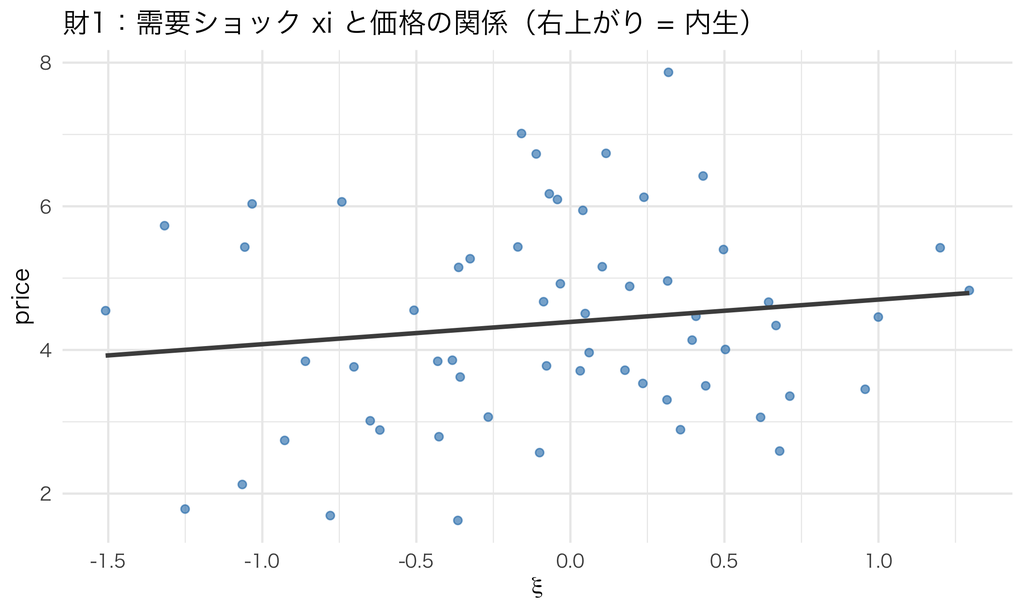

```r
# 価格 vs xi の散布図（財1）で内生性を可視化
df_endog <- data.frame(price = price[, 1], xi = xi[, 1])
ggplot(df_endog, aes(xi, price)) +
  geom_point(alpha = 0.6, color = "#1f77b4") +
  geom_smooth(method = "lm", se = FALSE, color = "grey30") +
  labs(title = "財1：需要ショック xi と価格の関係（右上がり = 内生）",
       x = expression(xi), y = "price")
```

**ノートこの課題での記述統計の意味**

シェアの範囲を見て「outside が大きすぎ／小さすぎ」を確認するのは大事だ。outside がほぼ0だと、値上げしても客が外へ逃げず、弾力性推定が不安定になる。逆に outside がほぼ1だと、そもそも誰も買っていないので情報が乏しい。適度に散っている（例：outside が3〜7割）のが健全である。

# Part 2：推定と合併分析（60点）

## 問4（15点）：縮小写像で $\delta$ を解く

$\sigma$ を固定したとき、シミュレーションシェアを観測シェアに一致させる $\delta$ を、BLP の縮小写像

$$\delta^{\text{new}}_{jt} = \delta_{jt} + \ln S^{\text{obs}}_{jt} - \ln s_{jt}(\delta; \sigma)$$

で解く関数 `solve_delta` を完成させよ。初期値は plain logit の Berry 反転 $\delta^{(0)} = \ln S^{\text{obs}} - \ln S^{\text{obs}}_0$。真の $\sigma$ で解いて、(a) 観測シェアを再現できること、(b) 市場1の収束の様子（誤差の対数プロット）を示せ。

```r
# ---- この関数を完成させる ----
solve_delta <- function(sigma, abar, S_obs, S0_obs, price, nu_p,
                        tol = 1e-11, maxit = 1000, trace_t = NULL) {
  Tn <- nrow(S_obs); Jn <- ncol(S_obs)
  delta <- ______                                # 【穴埋め】plain-logit 初期値 (T x J)
  trace <- NULL
  for (t in 1:Tn) {
    d <- delta[t, ]
    errs <- numeric(0)
    for (it in 1:maxit) {
      s_pred <- ______                           # 【穴埋め】現在の d でのシミュレーションシェア
      d_new  <- ______                           # 【穴埋め】縮小写像の更新式
      err    <- max(abs(d_new - d))
      errs   <- c(errs, err)
      d <- d_new
      if (err < tol) break
    }
    delta[t, ] <- d
    if (!is.null(trace_t) && t == trace_t) trace <- errs
  }
  list(delta = delta, trace = trace)
}
```

```r
# ---- 動作確認（穴埋め後に eval: true にして実行）----
res_true <- solve_delta(sigma_true, abar_true, S_obs, S0_obs, price, nu_p, trace_t = 1)

# (a) 観測シェアを再現できるか
recon_err <- max(abs(sapply(1:T, function(t)
  shares_from_delta(res_true$delta[t, ], price[t, ], abar_true, sigma_true, nu_p) - S_obs[t, ])))
cat("シェア再現の最大誤差:", recon_err, "\n")

# (b) 収束プロット（対数目盛）
df_trace <- data.frame(iter = seq_along(res_true$trace), err = res_true$trace)
ggplot(df_trace, aes(iter, err)) +
  geom_line(color = "#1f77b4") + geom_point(size = 0.8) +
  scale_y_log10() +
  labs(title = "縮小写像の収束（市場1）", x = "反復", y = "更新幅（対数）")
```

**警告よくあるバグ：log の中身がゼロ／負**

`log(s_pred)` の `s_pred` が数値的にゼロに潰れると `-Inf` が出て発散する。これはシェアが極端に小さい財で起きやすい。初期値を Berry 反転から取り、$\sigma$ が大きすぎなければ普通は起きないが、もし `NaN` が出たら (1) 初期値、(2) $\sigma$ の大きさ、(3) `outer` の符号を疑え。

## 問5（15点）：GMM 目的関数を $\sigma$ のグリッドで評価する

操作変数 $Z$（定数・$x$・コストシフター $w$・他製品の $x$ 和・$w$ 和）を作り、$\hat\delta(\sigma)$ をIV回帰して残差$\hat\xi$を得て、GMM目的関数を計算する。これは企業IDを省いた教育用の簡略IVである。標準的なBLP IVは、同一企業の他製品と他企業の製品の属性和を分ける。どちらにも、自財の$\xi$と無相関という除外制約が必要である。

```r
# 操作変数 Z（各行 = 製品×市場、市場 t を固定して財 j を回す順）
build_Z <- function(x, w) {
  Tn <- nrow(x); Jn <- ncol(x)
  Z <- matrix(0, Tn * Jn, 5)
  row <- 1
  for (t in 1:Tn) for (j in 1:Jn) {
    others <- setdiff(1:Jn, j)
    Z[row, ] <- c(1, x[t, j], w[t, j], sum(x[t, others]), sum(w[t, others]))
    row <- row + 1
  }
  Z
}
# 説明変数 X: 定数, x, price（price が内生）。Z と同じ並び順に！
build_X <- function(x, price) cbind(1, as.vector(t(x)), as.vector(t(price)))

Z    <- build_Z(x, w)
Xmat <- build_X(x, price)

gmm_step <- function(sigma, abar) {
  res <- solve_delta(sigma, abar, S_obs, S0_obs, price, nu_p)
  d <- as.vector(t(res$delta))                    # 【重要】t() で Z と同じ並びに
  W  <- solve(crossprod(Z))                        # (Z'Z)^{-1}
  ZX <- crossprod(Z, Xmat)                         # Z'X
  Zd <- crossprod(Z, d)                            # Z'delta
  theta1 <- ______                                 # 【穴埋め】IV-GMM: (X'ZWZ'X)^{-1} X'ZWZ'delta
  xi_hat <- d - Xmat %*% theta1
  g <- crossprod(Z, xi_hat)                        # Z'xi
  Q <- ______                                      # 【穴埋め】g' W g
  list(Q = as.numeric(Q), theta1 = as.vector(theta1), xi_hat = xi_hat)
}
```

```r
sigma_grid <- c(0.0, 0.4, 0.8, 1.2)
Q_vals <- sapply(sigma_grid, function(s) gmm_step(s, abar_true)$Q)
best_sigma <- sigma_grid[which.min(Q_vals)]
df_Q <- data.frame(sigma = sigma_grid, Q = Q_vals)
kable(df_Q, digits = 4)
cat("argmin:", best_sigma, "（真値 0.8）\n")

ggplot(df_Q, aes(sigma, Q)) +
  geom_line(color = "#1f77b4") + geom_point(size = 2) +
  geom_vline(xintercept = 0.8, linetype = "dashed") +
  labs(title = "GMM目的関数", x = expression(sigma), y = "Q")
```

**警告よくあるバグ第1位：delta と X の並び順のズレ**

`solve_delta` は $\delta$ を `T x J` 行列で返す。これを1本のベクトルに潰すとき、`as.vector(res$delta)`（列優先）と `as.vector(t(res$delta))`（行優先）で並びが変わる。`build_Z`・`build_X` が「市場 t を固定して財 j を回す」（＝行優先）で作っているなら、$\delta$ も `t()` してから `as.vector` すること。ここがズレると $\delta$ と $x$・$p$ の対応が壊れ、推定が無意味になる。**必ず両方の順序を一致させる**。

## 問6（10点）：plain logit と $\hat\sigma$ で弾力性を比較する

異質性を無視するとどんな間違いを犯すか。$\sigma = 0$（plain logit）と $\hat\sigma$（グリッドの argmin）のそれぞれで、**自己価格弾力性**の分布を計算して比較せよ。ヒストグラムを重ねて描き、「異質性を無視すると何を取り違えるか」を2〜3文で述べよ。

```r
# 推定した sigma のもとで、各製品の自己価格弾力性を計算する。
# 【重要】価格を動かすと delta も動く（delta に -alpha0*p が入るから）。
#         だから delta を「価格の関数」として作り直してから微小変化させる。
self_elasticities <- function(sigma, abar) {
  fit <- gmm_step(sigma, abar)
  th  <- fit$theta1                 # c(const, beta_x, coef_price)   coef_price = -alpha0
  xih <- matrix(fit$xi_hat, T, J, byrow = TRUE)   # 【t()並びなので byrow=TRUE】
  const <- th[1]; bx <- th[2]; cprice <- th[3]
  eps <- 1e-6
  out <- numeric(0)
  for (t in 1:T) {
    delta_of_p <- function(pv) const + bx * x[t, ] + cprice * pv + xih[t, ]
    p0 <- price[t, ]
    s0 <- shares_from_delta(delta_of_p(p0), p0, abar, sigma, nu_p)
    for (j in 1:J) {
      pj <- p0; pj[j] <- pj[j] + eps
      s1 <- shares_from_delta(delta_of_p(pj), pj, abar, sigma, nu_p)
      out <- c(out, (s1[j] - s0[j]) / eps * p0[j] / s0[j])   # eta_jj
    }
  }
  out
}

e_plain <- self_elasticities(0.0, abar_true)
e_hat   <- self_elasticities(best_sigma, abar_true)
rc_label <- sprintf("RC (sigma_hat=%.1f)", best_sigma)

df_e <- data.frame(
  elasticity = c(e_plain, e_hat),
  model = rep(c("plain logit (sigma=0)", rc_label), c(length(e_plain), length(e_hat)))
)
ggplot(df_e, aes(elasticity, fill = model)) +
  geom_histogram(alpha = 0.5, position = "identity", bins = 30) +
  labs(title = "自己価格弾力性の分布", x = "自己価格弾力性", fill = NULL)

cat("plain: mean", round(mean(e_plain), 3), " sd", round(sd(e_plain), 3), "\n")
cat("RC   : mean", round(mean(e_hat), 3),   " sd", round(sd(e_hat), 3),   "\n")
```

**ヒントヒント：何に注目すべきか**

平均だけでなく**ばらつき（sd）**を見よ。plain logit は「価格感応度は全員同じ」と仮定するので、弾力性の分布の形が真実とずれる。とくに、高シェア財と低シェア財、高価格財と低価格財で弾力性がどう違うかに注目。異質性を入れたモデルの方が、真の弾力性分布に近い形になるはずだ。

## 問7（15点）：財1・財2の合併分析

推定した需要（`abar_true` と `sigma = 0.8` を使ってよい）を使い、4財市場での合併を分析せよ。手順：(1) 観測価格から Bertrand-Nash の FOC で限界費用を逆算、(2) 財1・財2を統合（所有行列の書き換え）、(3) 新均衡を固定点反復で解く。価格上昇率と diversion ratio の表を作れ。

まず合併分析用の需要（4財市場）を作る。**Part 1 とは別の市場設定**（下に用意した）を使う。

```r
# ---- 合併分析用の4財市場（推定済みパラメータを流用）----
abar_m  <- 0.5;  sigma_m <- 0.8;  Jm <- 4
nu_m <- rnorm(ns)                         # この市場のシミュレーション個人
xbeta_xi  <- c(3.0, 2.6, 2.9, 2.7)        # 各財の x'beta + xi（価格を除く平均効用）
mc_true_m <- c(1.0, 1.1, 1.2, 0.9)        # 真の限界費用（逆算の答え合わせ用）

# 個人選択確率 (ns x Jm)
choice_probs <- function(p) {
  alpha_i <- exp(abar_m + sigma_m * nu_m)
  V <- sweep(-outer(alpha_i, p), 2, xbeta_xi, "+")
  eV <- exp(V)
  eV / (1 + rowSums(eV))
}
agg_shares <- function(p) colMeans(choice_probs(p))

# シェアの価格微分 (Jm x Jm), 要素[k,j] = ds_k/dp_j
dS_dp <- function(p) {
  alpha_i <- exp(abar_m + sigma_m * nu_m)
  sij <- choice_probs(p)
  M <- matrix(0, Jm, Jm)
  for (j in 1:Jm) for (k in 1:Jm) {
    if (k == j) M[k, j] <- mean(-alpha_i * sij[, j] * (1 - sij[, j]))
    else        M[k, j] <- ______                # 【穴埋め】k != j のとき ds_k/dp_j
  }
  M
}

owner_matrix <- function(groups) outer(groups, groups, function(a, b) as.numeric(a == b))

# FOC: s - Delta(p - mc) = 0,  Delta[j,k] = -Omega[j,k] * ds_k/dp_j
#      <=> p = mc + Delta^{-1} s
markup_pieces <- function(p, groups) {
  M <- dS_dp(p)
  Omega <- owner_matrix(groups)
  Delta <- ______                                 # 【穴埋め】-(Omega * t(M))
  list(Delta = Delta, s = agg_shares(p))
}

# 固定点反復で均衡を解く
solve_equilibrium <- function(mc, groups, p_init, tol = 1e-11, maxit = 2000) {
  p <- p_init
  for (it in 1:maxit) {
    mp <- markup_pieces(p, groups)
    p_new <- ______                               # 【穴埋め】mc + solve(Delta, s)
    if (max(abs(p_new - p)) < tol) return(list(p = p_new, iters = it, ok = TRUE))
    p <- p_new
  }
  list(p = p, iters = maxit, ok = FALSE)
}
```

```r
# ---- 合併前均衡 → mc 逆算 → 合併後均衡 ----
groups_pre  <- c(1, 2, 3, 4)
groups_post <- c(1, 1, 3, 4)   # 財1・財2が合併

eq_pre <- solve_equilibrium(mc_true_m, groups_pre, p_init = mc_true_m * 1.5)
p0 <- eq_pre$p; s0 <- agg_shares(p0)

# mc 逆算（観測価格から）
mp0 <- markup_pieces(p0, groups_pre)
mc_implied <- p0 - solve(mp0$Delta, mp0$s)
cat("mc 逆算の最大誤差:", max(abs(mc_implied - mc_true_m)), "\n")

# 合併後
eq_post <- solve_equilibrium(mc_implied, groups_post, p_init = p0)
p1 <- eq_post$p; s1 <- agg_shares(p1)

# diversion ratio
M0 <- dS_dp(p0)
diversion <- function(j, k) -M0[k, j] / M0[j, j]

merger_tbl <- data.frame(
  product    = paste0("財", 1:4),
  price_pre  = round(p0, 3),
  price_post = round(p1, 3),
  pct_change = round((p1 - p0) / p0 * 100, 2)
)
kable(merger_tbl, caption = "合併の価格効果")
cat("D(財1->財2):", round(diversion(1, 2), 3),
    " D(財2->財1):", round(diversion(2, 1), 3), "\n")
```

**警告よくあるバグ：所有行列の書き換えミス**

合併は `groups` ベクトルの該当要素を同じ番号にするだけだ（`c(1,2,3,4)` → `c(1,1,3,4)`）。ここで財2を財1と同じ「1」にし忘れたり、間違って財3まで巻き込んだりすると、全く違う合併を分析してしまう。また `Delta <- -(Omega * t(M))` の **転置 `t(M)` を忘れる**と、`ds_k/dp_j` と `ds_j/dp_k` を取り違えて符号・非対称性が壊れる。合併前の mc 逆算が真値と一致するか、が最良のチェックだ（一致しなければどこか間違っている）。

## 問8（10点）：審査官向けの1段落

あなたは競争当局の審査官だとする。問7の推定結果（価格上昇率、diversion ratio、必要ならUPP や消費者余剰の変化）に基づいて、**この財1・財2の合併を承認すべきか**を1段落（5〜8文）で論じよ。数値を根拠に引くこと。「どういう条件なら判断が変わるか」（例：効率化＝限界費用の低下があれば、diversion がもっと低ければ）にも触れると良い。

```r
# 判断材料を1つの表にまとめておくと書きやすい
# （ここでは価格上昇率と diversion の報告で十分）
```

**ノート経営・政策への含意（この課題の締め）**

上の審査官パラグラフが、そのまま「経営・政策への含意を3行で書け」の役割を果たす。第5回のゲスト講義（公正取引委員会）で、実際の審査ではこの種の分析がどう提出され、どこが争点になるのかを聞く。今日あなたが計算した数字が、現実の企業結合審査の言語であることを意識してほしい。

## 提出方法

- この `.qmd` の穴埋め（`______` と `#| eval: false`）をすべて埋め、`#| eval: false` を外して最後まで render できる状態にする。
- 各問の出力（表・図）とコメントを含めること。
- render した HTML を提出。

**重要配点（合計100点）**